# スモールワールド，ラージワールド

コロンブスには教養があったが，地球の周長は$30,000$kmだと思っていた（実際は$40,000$km）。到着したところは目的地のアジアではなかったが，彼の「スモールワールドモデル」から見積もった航海距離の分しか食料や飲料水を持ち込まなかっただろうから，そのモデルの誤りはラッキーだったと言わざるを得ない。

[figure not shown]

Figure 2.1

スモールワールドは自己完結型のモデル世界である。一方，ラージワールドはスモールワールドでイメージされない事象も発生する，より広い文脈である。モデルの仮定が実世界を近似するものである時，モデルはラージワールドでもうまくいく。

# 2.1. 八岐データの園

ベイズ分析は八岐データの園である。何が起きたかを知ると，この事実に反する可能性が削ぎ落とされる。こうして，知識とロリ的に整合する候補が残る。しかし，このアプローチが，ラージワールドでの正解かどうかは保証されない。しかし，スモールワールドでの最適解であることは保証される。

## 2.1.1. 可能性の数え上げ

$4$つの玉が入った袋がある。玉は青と白だがそれぞれ何個か分からない。可能性は$5$つあることが分かるだけである。復元抽出で$3$回玉を取り出すと「青白青」であった。

袋の中身が仮に「青白白白」だとすると，$3$度の復元抽出ではFigure 2.2のように，$64$通り（$=4^3$）の抽出パターンが考えられる。

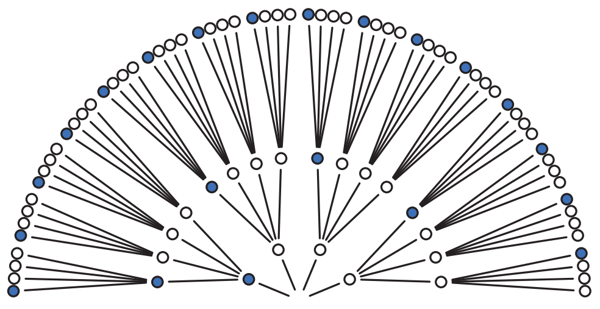

Figure 2.2

これらのうち，「青白青」の順になっているものは$3$通りしかない（Figure 2.3）。

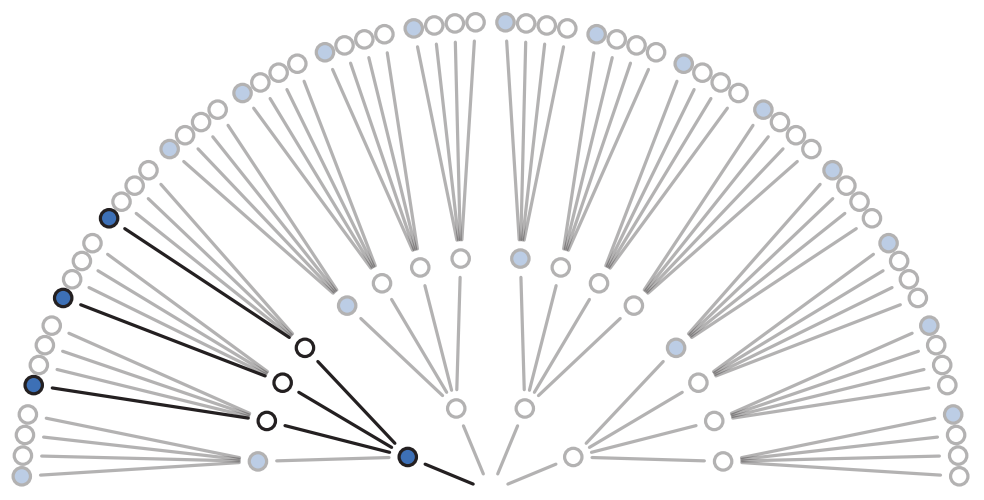

Figure 2.3

他の可能性について同様に考えれば，例えば，中身が「白白白白」と「青青青青」の場合は観察データになるパターンは$0$通りである。したがって，これら$2$つの可能性は除外できる。Figure 2.4は残り$3$つの可能性についての抽出パターンである。

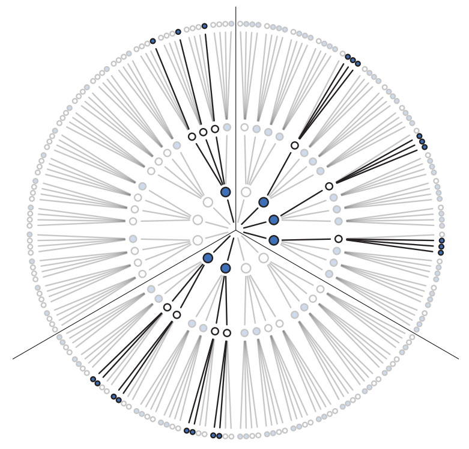

Figure 2.4

Figure 2.4からも明らかであるが，それぞれの可能性から観察データが生じるパターンを数え上げれば，次のようになる。

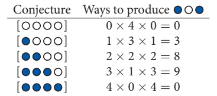

## 2.1.2. 事前情報の利用

新たな抽出で「青」が出たとしよう。先のデータと合わせれば全体で「青白青青」という観察データとみなせる。あるいは，各可能性に対する数え上げ$(0, 3, 8, 9, 0)$を，新たな観察データに基づいてアップデートする。これら二つの方法は，観察が独立である限り，数学的には等価である。

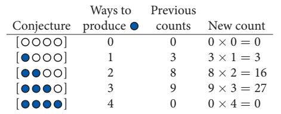

1. 事前の観測データ$D_{prior}$に対応する各可能性のパターン$W_{prior}$を求める。
2. 新たな観測データ$D_{new}$に対応する各可能性のパターン$W_{new}$を求める。
3. $D_{prior}$と$D_{new}$の両方に対応する各可能性のパターンを積$W_{prior}\times W_{new}$を算出する。

一般に，事前データと新たなデータの出処が異なる。ここで，玉の工場の従業員が「青はすごく少ない」と意見したとする。工場では，「青青青白」の袋$1$つに対し，「青青白白」の袋を$2$つ，「青白白白」の袋を$3$つ製作している。また，「青」と「白」は必ず$1$つずつ入っているという。このことから数え上げをアップデートできる。

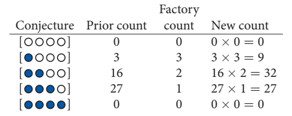

「青青白白」が最も有り得そうだが，「青青青白」とはかろうじてあるという程度である。安心して正解を決定するにはどうすればいいだろうか。

**無差別原理（principle of indifference）**：より有り得そうと思える理由が特になければ，等しく重み付けするという考え方。“無知”の表現法の$1$つ。非ベイジアンでは暗黙の了解的な方法。

## 2.1.3. 数え上げから確率へ

数え上げのままでは扱いが難しい。データが追加されるごとに数え上げる数値はどんどん大きくなる。したがって，相対化する必要があり，それが確率である。アップデートされる確率は，次のように定義できる。

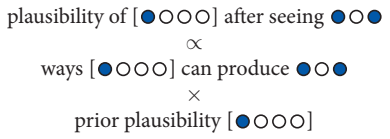

青の割合を$p$と表すことにすれば，例えば「青白白白」の袋は$p = 1/4 = 0.25$と表される。$D_{new}$を「青白青」とすれば，

$$D_{new}後のpの尤もらしさ \propto pがD_{new}を生じるパターン \times pの事前の尤もらしさ$$

となる。全ての尤もらしさの和は$1$になるように，尤もらしさを規格化して確率を定める。

$$D_{new}後のpの尤もらしさ = \frac{pがD_{new}を生じるパターン \times pの事前の尤もらしさ}{積の和}$$

これまでの例で計算すれば，次のようになる。

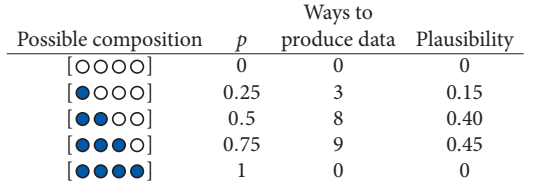

```r
ways = c(0, 3, 8, 9, 0)
ways / sum(ways)
```

```
## [1] 0.00 0.15 0.40 0.45 0.00
```

ここまでに登場した概念の用語は以下の通り：

- $p$はパラメータ（parameter）。データ把握のための指標。
- $p$の相対頻度は尤度（likelihood）。
- $p$の事前の尤もらしさは事前確率（prior probability）。
- $p$のアップデートされた尤もらしさは事後確率（posterior probability）。

# 2.2. モデリング

手のひらサイズの地球儀があるとしよう。海はどのくらいの表面積を占めているのか。地球儀を投げ上げて，キャッチした時に右手人差し指が海（Water）か陸（Land）のいずれに触れているかを記録する。これを繰り返す。$9$回実施した際のデータ列は「WLWWWLWLW」となったとする。

モデルは仮定でできている。ベイジアンモデルのデザインでは$3$つのステップからなるデザインループが実行される。

1. データストーリ：データはどのように発生したか。
2. 更新：データを与えて，モデルを教育する
3. 評価：モデル修正のためのチェック

## 2.2.1. データストーリ

ベイジアンデータ分析は「データ由来に関するストーリ作り」である。その意味で，ストーリは記述的であり，場合によっては因果的であることもある。サンプリングプロセスや現実性を踏まえて記述する。

1. 地球儀上で海が占める真の割合を$p$とする。
2. 一度のトスでWとなる確率は$p$であり，Lとなる確率は$1-p$である。
3. 各トスは独立。

このデータストーリが確率モデルに翻訳される。

## 2.2.2. ベイズ更新

データに基づいて，事前確率を事後確率にアップデートするプロセスがベイズ更新である。どの$p$に対しても同じ尤もらしさをまずは仮定する（Figure 2.5の左上の点線）。最初のトスの結果が「W」で，各$p$の尤もらしさを更新したものが実線で表されている。$p=0$の尤もらしさは明らかに$0$である。同様に$p>0.5$の尤もらしさは上昇する。

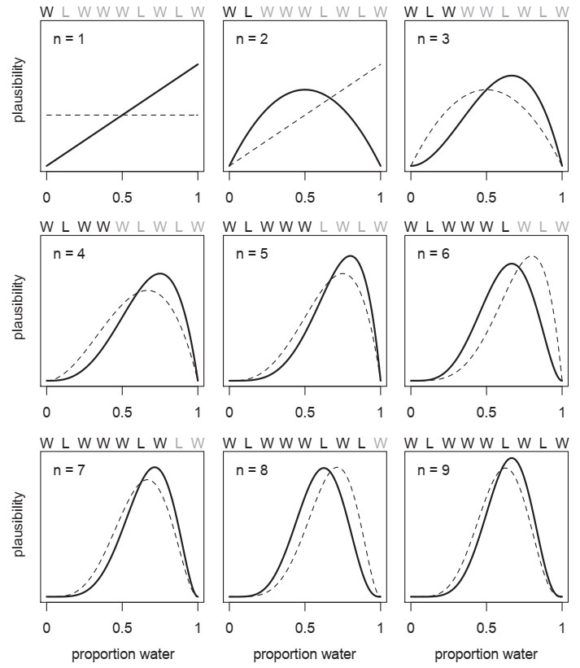

Figure 2.5

この更新をデータごとに行い，ベイジアンモデルは学習していく。「W」が得られると曲線は右に動き，「L」が得られると左に動く。各回の曲線は次回の推論のきっかけとなる。

有効な統計的推定値を得るには，非ベイズ統計学の場合，小さなサンプルサイズでは問題ありとされる。一方，ベイズ推定値はどんなサンプルサイズでも妥当である。これはデータが多くなくても良いという意味ではない。大事なのは事前確率である。事前確率の設定が悪ければ，推論はミスリードすることになる。

## 2.2.3. 評価

ベイジアンマシンはスモールワールドの範囲では完全な推論を形成する。しかし，油断せずに結果をチェックしなければならない。

第一に，モデルの良さを保証するものではない。推定値はあくまでもモデルという条件付きのシロモノである。モデルが違えば，見え方は異なる。第二に，モデルの挙動を批判的に見るべきである。例えば，データの順序が違ってもベイズ更新の最終結果が同じになるが，順序が推論とは無関係である場合にのみこの結果は真である。それゆえ，データの諸側面からモデル推論をチェックするのは重要なことであり，このチェックは創造性を要する。ゴーレムが最も不得意とするものである。

モデルの仮定はどこまでいっても正しくない。したがって，モデルが真であるかどうかをチェックすることはできない。真でなくても，モデルは有効な推定値をはじき出すかもしれない。

ベイズ推論は優れた推論方法だと思われるが，期待するほど強力ではない。普遍的な保証を与える推論方法はない。数学自体が現実性に自由にアクセスするものではない。それは数学が発見されるものではなく，発明されるものだからである。

# 2.3. モデル要素

青玉と白玉の問題では以下のことを考えた。

1. 各可能性が一度の観測値を出現させるパターンの数え上げ
2. 各可能性がデータ全体を出現させるパターンの数え上げ
3. 各可能性の尤もらしさの初期値

統計モデリングでは，相対的なパターン数を表す確率分布や仕掛けを選択することになる。上記の$3$要素はベイジアンモデルでは次のように呼ばれる。

1. 尤度関数
2. パラメータ
3. 事前分布

## 2.3.1. 尤度

尤度はデータの尤もらしさを具体的に示す数式である。換言すれば，各可能性の尤もらしさを表すものである（地球儀の例で言えば，パターンの相対度数に相当する）。データストーリに関する仮定から尤度関数を立てることになる。

地球儀実験では$n$回のトスでWとLのデータ列を観測した。毎回のトスは独立しており，Wの確率が毎回のトスで一定であると仮定すれば，確率論的には「二項分布（binomial distribution）」が利用できる。$n$回のトスで出現確率$p$のWが$w$回観察される確率は次式で表される。

$$P(w | n, p) = \frac{n!}{w! (n-w)!} p^w (1-p)^{n-w}$$

Rでの利用例は次の通り。

```r
dbinom(6, size = 9, prob = 0.5)
```

```
## [1] 0.1640625
```

## 2.3.2. パラメータ

二項分布は$p$，$n$，$w$という入力が要求される。地球儀問題においては，データは$n$と$w$であり，得たい推定量（パラメータ）が$p$である。但し，分野によっては推定したいパラメータが独特な場合がある。例えば，フィールド生物学では「標識放流（mark recapture）」という集団サイズ（二項分布での$n$）を推定するための手続きが用いられる。

統計モデリングでは，データに関するほとんどの問いはパラメータによって直接解決される。

- 群間差はどうなっているか？
- 処置と結果の関連はどのくらい大きいのか？
- 処置の効果は共変量に依存しているか？
- 群間での変動はどのくらいか？

## 2.3.3. 事前分布

推定したいパラメータごとに事前分布を設定する。事前分布は各可能性の初期値である。以前の推定値を持っていれば，それを事前分布として利用できる（Figure 2.5）。

事前分布を無差別原理に従って設定する場合によく用いられるのは一様分布である。

$$P(p) = \frac{1}{1-0} = 1$$

一般に，$a$から$b$までの一様分布は$1/(b-a)$となる。保守的な事前分布は弱情報事前分布（weakly informative prior）と呼ばれることがある。中には主観的信念に基づいて事前分布を選択すべきというベイズ学派（主観的ベイジアンアプローチ）もあるが，科学では稀である。但し，主観的な決定は科学のあちこちで見られる。有意性検定の基礎になっているサンプリングの反復という考え方が主観的でないならば，事前分布やベイジアンデータ分析もまた主観的でない。事前分布は仮定であるから，それ以外使えないというくらいの強い言い分が特にないならば，別の事前分布を試しても良い。

歴史的には，ベイズ推論は事前分布の恣意性が攻撃されてきた。しかし，事前分布以上に尤度の選択もまた同罪であり，この点で非ベイジアンモデルも等しく責められるべきである。

## 2.3.4. 事後分布

データで条件付けられたパラメータの相対的な尤もらしさが事後分布である。ベイズの定理（Bayes’ theorem）は事前分布から事後分布への更新ルールである。

単純化のため，既知情報全体を$D$（地球儀問題では$w$や$n$），パラメータを$p$とおくと，同時確率$P(D, p)$に関して，次の式が成立する。

$$P(D, p) = P(D|p)P(p)$$

形式的には次の式も成立する。

$$P(D, p) = P(p|D)P(D)$$

これら$2$つの式の右辺は等しいので，以下の事後確率に関する式を得る。

$$P(p|D) = \frac{P(D|p)P(p)}{P(D)}$$

分母の$P(D)$は，事後分布の積分が$1$になるための正規化の役割がある。数学的には，

$$P(D) = \int Pr(D|p) P(p) dp = E\left[ P(D|p) \right]$$

となることから，$P(D)$は尤度の期待値である（周辺尤度 marginal likelihoodと呼ばれる）。

重要なのは，事後分布が事前分布と尤度の積に比例するということである。これは青玉・白玉の出現パターンの数え上げで掛け算を用いたのと同じ理由である。Figure 2.6はこの特徴を示している。

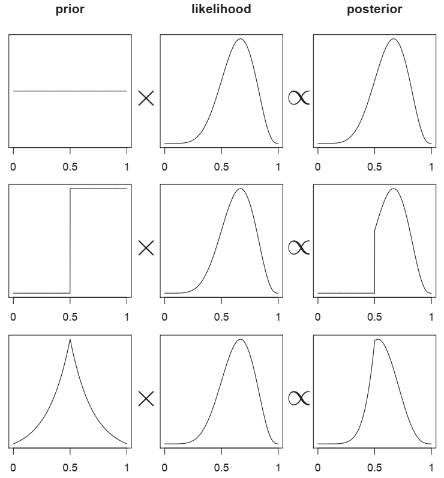

Figure 2.6

# 2.4. モデル実行

ベイジアンモデルは，尤度，パラメータ，事前分布を組み込んだゴーレムであり，ベイズの定理に従って事後分布を生むマシンである。しかし，現代科学におけるモデルの多くはそう簡単に数学的に表現できない。そのため，解析的手法に近似する数的なアプローチが必要になる。

1. グリッド近似
2. 二次近似
3. マルコフ連鎖モンテカルロ（MCMC）

## 2.4.1. グリッド近似

グリッド近似は，パラメータが連続量となる時，パラメータの値を有限のグリッドにして連続的な事後分布の近似を得る方法である。パラメータをある特定の値にすれば，その事後確率は簡単に計算できることを利用する。グリッドに区切った各パラメータ値に対して計算を行えば，近似的な事後分布を得られる。（但し，グリッド近似は単純であるがゆえにベイズ更新の基本的な理解のためには良い教育的ツールである反面，実用には向かない。）

手順は以下の通り：

1. グリッド数を決める。
2. グリッドで区切られた各パラメータ値における事前分布の値を算出する。
3. 各パラメータ値での尤度を算出する。
4. 各パラメータ値での（規格化される前の）事後分布の値を算出する。
5. 事後分布を規格化する。（しかし，この規格化はグリッド数の影響を受けるので，縦軸を確率密度にする調整を行わなければならない。）

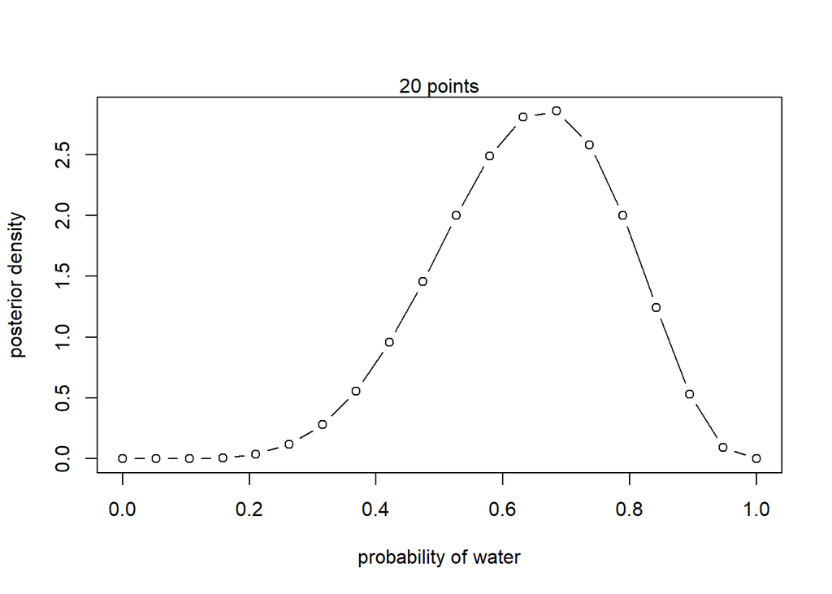

```r
p_grid = seq(from = 0, to = 1, length.out = 20)   # グリッド数=20
prior = rep(1, 20)    # 事前分布（一様分布）の値
likelihood = dbinom(6, size = 9, prob = p_grid)   # 尤度の値
unstd.posterior = likelihood * prior    # 規格化前の事後分布の値
posterior = unstd.posterior / sum(unstd.posterior)    # 事後分布の規格化
posterior = posterior * length(p_grid)    # 確率⇒確率密度に変換
plot(p_grid, posterior, type = "b", xlab = "probability of water", ylab = "posterior density")
mtext("20 points")
```

グリッドを細かくすれば精度は高まるが，$100$以上ではあまり大差ない。また，Figure 2.6のように事前分布が異なれば，事後分布も異なることが分かる。

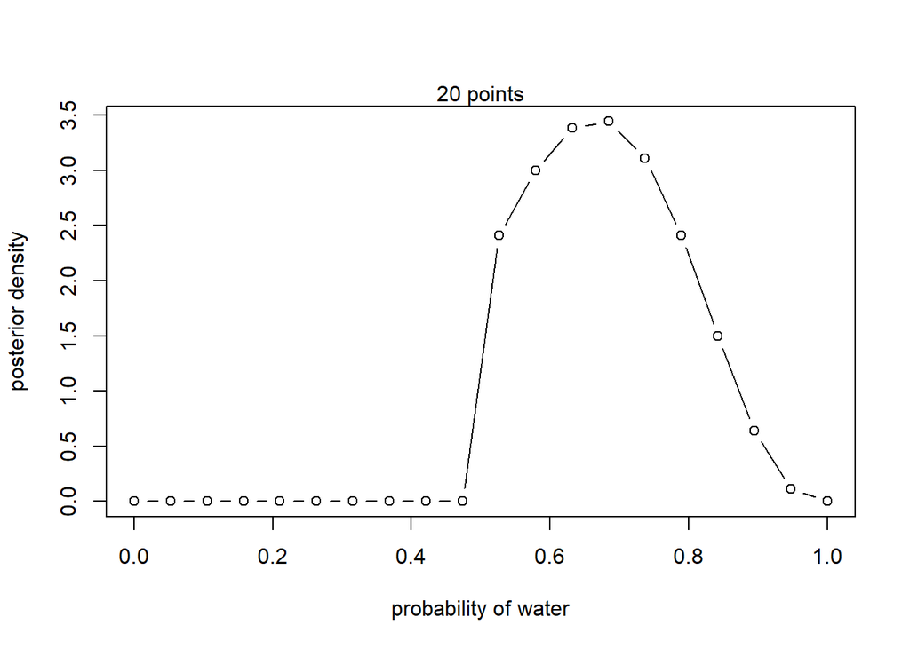

```r
p_grid = seq(from = 0, to = 1, length.out = 20)   # グリッド数=20
prior = ifelse(p_grid < 0.5, 0, 1)    # 事前分布（閾値分布）の値
likelihood = dbinom(6, size = 9, prob = p_grid)   # 尤度の値
unstd.posterior = likelihood * prior    # 規格化前の事後分布の値
posterior = unstd.posterior / sum(unstd.posterior)    # 事後分布の規格化
posterior = posterior * length(p_grid)    # 確率⇒確率密度に変換
plot(p_grid, posterior, type = "b", xlab = "probability of water", ylab = "posterior density")
mtext("20 points")
```

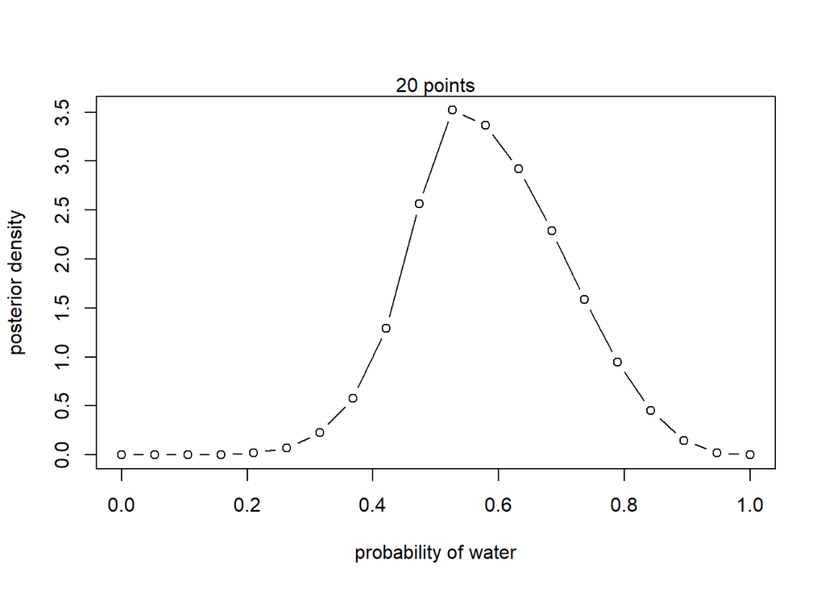

```r
p_grid = seq(from = 0, to = 1, length.out = 20)   # グリッド数=20
prior = exp(-5 * abs(p_grid - 0.5))    # 事前分布（指数分布）の値
likelihood = dbinom(6, size = 9, prob = p_grid)   # 尤度の値
unstd.posterior = likelihood * prior    # 規格化前の事後分布の値
posterior = unstd.posterior / sum(unstd.posterior)    # 事後分布の規格化
posterior = posterior * length(p_grid)    # 確率⇒確率密度に変換
plot(p_grid, posterior, type = "b", xlab = "probability of water", ylab = "posterior density")
mtext("20 points")
```

## 2.4.2. 二次近似

正規分布は平均値と分散の$2$つのパラメータで完全に記述できるので便利である。事後分布のピーク近傍では正規分布の形状に近似すると見立てる方法が二次近似と呼ばれる。この名称は，正規分布の対数が放物線の形状となることに由来する。線形回帰などポピュラーな手続きで二次近似は有用であり，グリッド近似や後述のMCMCよりも計算が少なくて済む。

手順は以下の通り：

1. 事後分布のピーク（最頻値）を見つける。（事後分布をあたかも登るような最適化アルゴリズムを用いる）
2. ピーク近傍の曲率を推定する。（事後分布の二次近似を計算する）

手順1はいわゆるMAP（Maximum a posteriori）である。rethinkingパッケージのmap関数を用いる。

```r
# library(rethinking)
globe.qa = map(
  alist(
    w ~ dbinom(9, p),    # 尤度（二項分布）
    p ~ dunif(0, 1)      # 事前分布（一様分布）
  ),
  data = list(w = 6)
)
precis(globe.qa)    # 二次近似の要約を表示
```

```
##   Mean StdDev 5.5% 94.5%
## p 0.67   0.16 0.42  0.92
```

map関数を使うには，尤度と事前分布でフォーミュラを定義し，データリストを観測値で定義する。precis関数は二次近似の要約を表示する。MAP値は$p=0.67$，曲率は$0.16$と出力されている。これは「事後分布が正規分布であると仮定すると，ピークが$0.67$，標準偏差が$0.16$である」という意味である。（残りの$2$つの出力は$89\%$区間を表している。）

地球儀問題での設定において，解析的には事後分布はベータ分布になる。

$$\begin{eqnarray*}
f(p|n, w) &\propto& f(w | n, p)f(p) \\
&\propto& f(w | n, p) \\
&\propto& p^w (1-p)^{n-w} \\
&=& p^{\alpha-1} (1-p)^{\beta-1}
\end{eqnarray*}$$

$\alpha = w + 1$，$\beta = n - w + 1$である。dbeta関数と二次近似の結果を比較してみる。

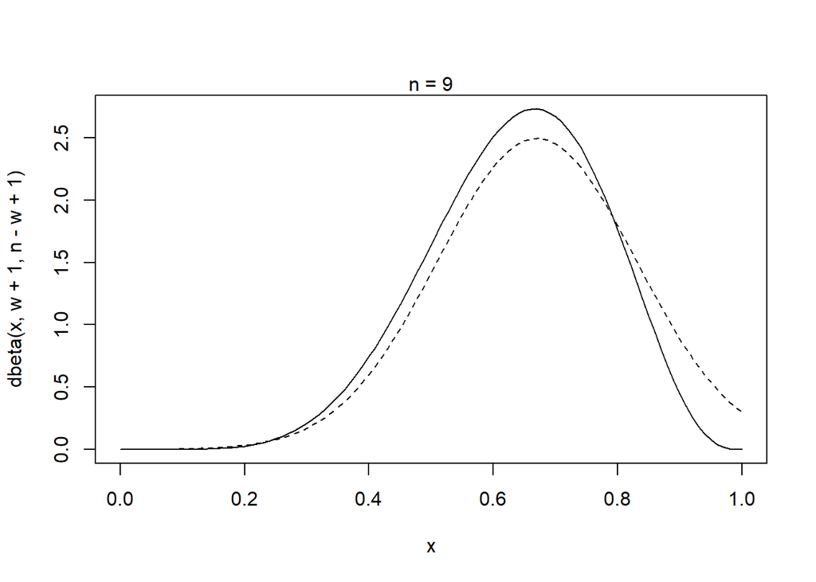

```r
w = 6
n = 9
curve(dbeta(x, w + 1, n - w + 1), from = 0, to = 1)   # 解析解
curve(dnorm(x, 0.67, 0.16), lty = 2, add = TRUE)    # 二次近似
mtext("n = 9")
```

少なくとも$1$度はLを観測しているので，$p=1$という可能性はあり得ない。ベータ関数（解析解）はこれを表せているが，二次近似では扱えていない。しかし，観測データを増やすと二次近似は良くなることが知られている。$n=18$，$n=36$でWが出現する割合を同じとした場合と比較する。

```r
globe.qa = map(
  alist(
    w ~ dbinom(18, p),    # 尤度（二項分布）
    p ~ dunif(0, 1)      # 事前分布（一様分布）
  ),
  data = list(w = 12)
)
precis(globe.qa)
```

```
##   Mean StdDev 5.5% 94.5%
## p 0.67   0.11 0.49  0.84
```

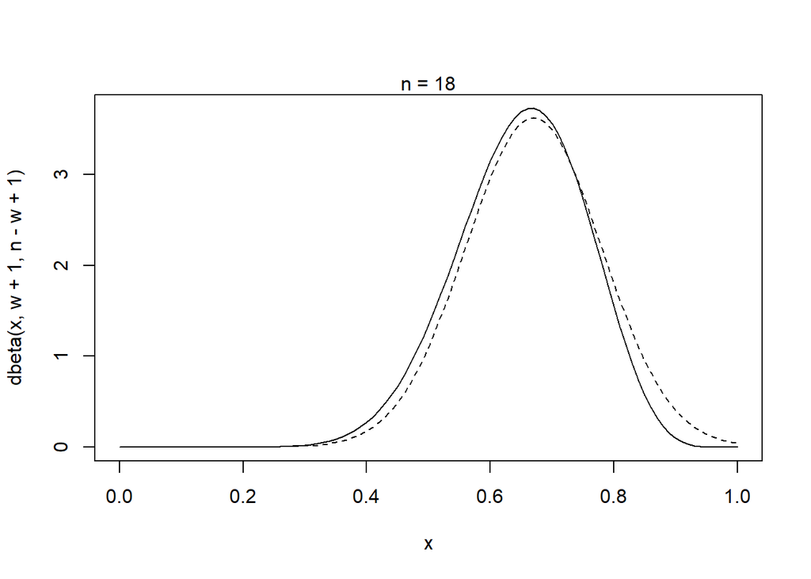

```r
w = 12
n = 18
curve(dbeta(x, w + 1, n - w + 1), from = 0, to = 1)   # 解析解
curve(dnorm(x, 0.67, 0.11), lty = 2, add = TRUE)    # 二次近似
mtext("n = 18")
```

```r
globe.qa = map(
  alist(
    w ~ dbinom(36, p),    # 尤度（二項分布）
    p ~ dunif(0, 1)      # 事前分布（一様分布）
  ),
  data = list(w = 24)
)
precis(globe.qa)
```

```
##   Mean StdDev 5.5% 94.5%
## p 0.67   0.08 0.54  0.79
```

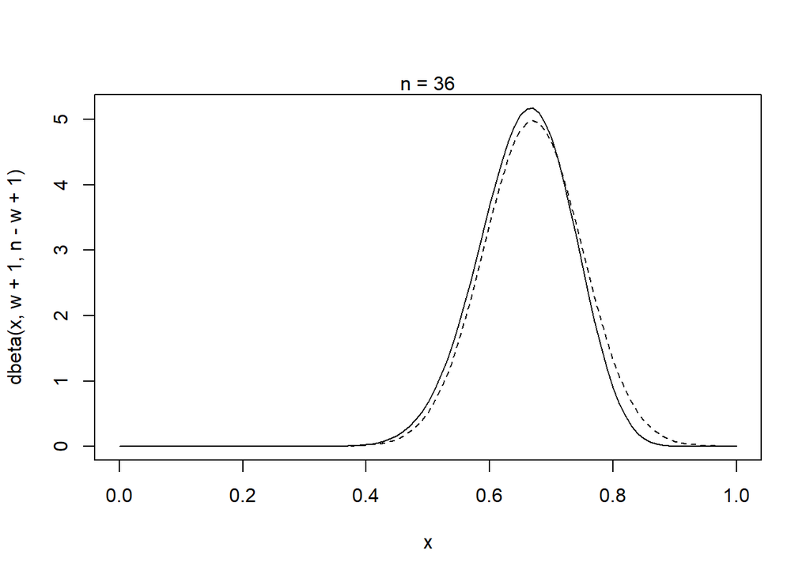

```r
w = 24
n = 36
curve(dbeta(x, w + 1, n - w + 1), from = 0, to = 1)   # 解析解
curve(dnorm(x, 0.67, 0.08), lty = 2, add = TRUE)    # 二次近似
mtext("n = 36")
```

伝統的な統計的手続きでは，サンプルサイズに神経質になりがちであるが，二次近似についてはベイズ統計学でも同じ悩みを抱えることになる。グリッド近似は小サンプルでもうまくいくが，次のMCMCは実用性も兼ね備えている点で優れている。

## 2.4.3. マルコフ連鎖モンテカルロ

MCMCは高度に複雑なモデルを扱える手法の総称である（詳細は別の章で）。MCMC自体は1990年代以前に誕生していたが，コンピュータパワーが追いついていなかった。MCMCは事後分布を直接計算もしくは近似するのではなく，事後分布からサンプリングするだけである。そのヒストグラムから事後分布の概形を作り上げる。様々な推定はこれらのサンプルを直接用いて行う。

# 2.5. まとめ

ベイズ推論のターゲットは事後確率分布である。尤度（あるパラメータ値の下でのデータの確率）と事前分布（パラメータの尤もらしさ）から事後分布を導く計算規則がベイズの定理である。

ベイズモデルの実際は，数的テクニック（グリッド近似，二次近似，MCMC）によりデータフィットさせる。それぞれの方法に長所短所がある。

# 2.6. 練習問題

> EASY

##### 【2E1.】

「月曜日に雨が降る確率」に対応する式は次のうちどれか？

1. $P(rain)$
2. $P(rain | Monday)$
3. $P(Monday | rain)$
4. $P(rain, Monday) / P(Monday)$

2と4。

##### 【2E2.】

$P(Monday | rain)$に対応する表現は次のうちどれか？

1. 月曜日に雨が降る確率
2. 月曜日である条件の下で雨が降る確率
3. 雨が降っているという条件の下で月曜日である確率
4. 月曜日であり，かつ雨が降っている確率

3。

##### 【2E3.】

「雨が降っているという条件の下で月曜日である確率」に対応する式は次のうちどれか？

1. $P(Monday | rain)$
2. $P(rain | Monday)$
3. $P(rain | Monday) P(Monday)$
4. $P(rain | Monday) P(Monday) / P(rain)$
5. $P(Monday | rain) P(rain) / P(Monday)$

1と4。

##### 【2E4.】

ベイズ統計学者Bruno de Finetti (1906-1985) は確率論に関する自身の著作の冒頭でこう宣言した。「**確率は実在しない。（PROBABILITY DOES NOT EXIST.）**」 原著で大文字表記されていることから，de Finettiは声を大にして言いたかったのだろう。彼が言いたかったのは，確率は，知識の制約に由来する不確実さを記述する装置だということである。決して客観的なリアリティを持つものではない。この宣言に基づいて，地球儀問題を考察しなさい。「水の確率が$0.7$である」というのはどういうことなのだろうか？

地球の表面のうち海が占める割合そのものが$0.7$という意味ではない。地球儀（地球のモデル）というスモールワールドで，かつ，測定の精度や正確さの限界も加わるため，それらによって知ることができるデータ及び知識は現実そのものではない。確率が$0.7$であるというのは，そういった制約条件の下で最も尤もらしいと見積もられた数量的信念である。

> MEDIUM

##### 【2M1.】

地球儀問題を考えよう。以下の観察データについて，事後分布を計算し，グリッド近似をプロットしなさい。$p$の事前分布は一様分布を仮定しなさい。

1. W, W, W
2. W, W, W, L
3. L, W, W, L, W, W, W

グリッド数を$100$とし，各グリッド（p_grid）での事前分布上の確率密度（prior）を求めておく。事後分布上での確率密度を算出するcompute_posterior関数と，事後分布を表示するplot_posterior関数を定義する。

```r
p_grid = seq(from = 0, to = 1, length.out = 100)
prior = rep(x = 1, length = length(p_grid))

compute_posterior = function(w, n, prior, p = p_grid) {
  likelihood = dbinom(x = w, size = n, prob = p)
  unstandardized.posterior = likelihood * prior
  posterior = unstandardized.posterior / sum(unstandardized.posterior)
  return(posterior * length(p))    # 確率⇒確率密度に変換
}

plot_posterior = function(x, y) {
  plot(x = x, y = y, type = "b", xlab = "Probability of Water", ylab = "Posterior Density")
  title = paste(length(x), "Points")
  mtext(title)
}
```

###### 1.

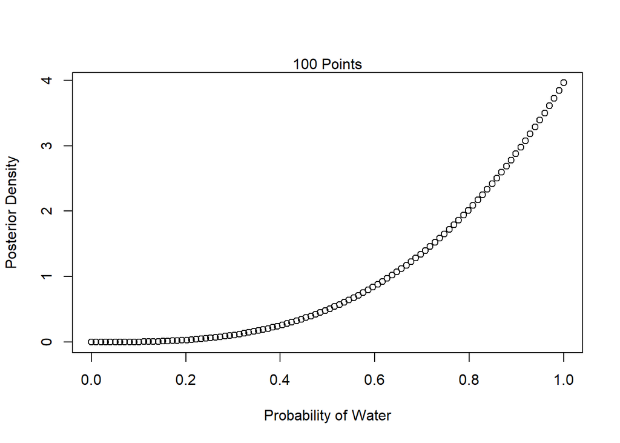

```r
w = 3
n = 3
posterior = compute_posterior(w = w, n = n, prior = prior)
plot_posterior(x = p_grid, y = posterior)
```

###### 2.

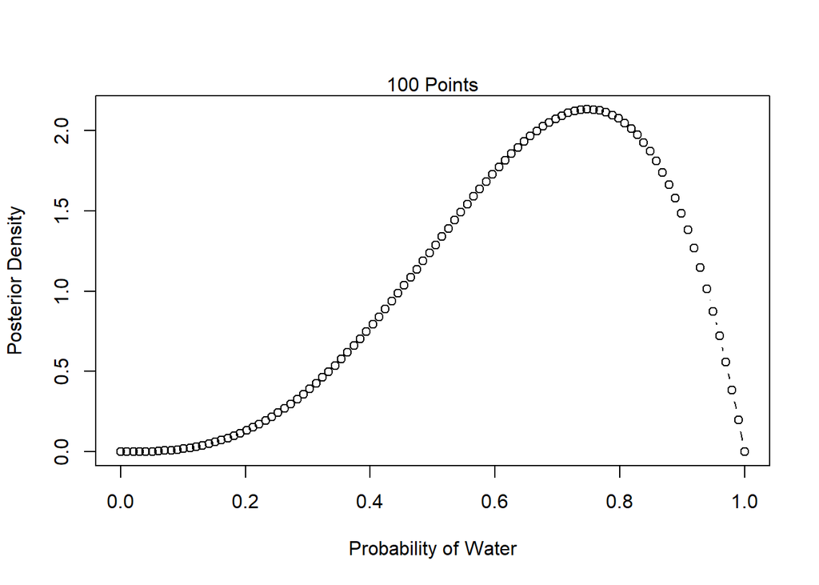

```r
w = 3
n = 4
posterior = compute_posterior(w = w, n = n, prior = prior)
plot_posterior(x = p_grid, y = posterior)
```

###### 3.

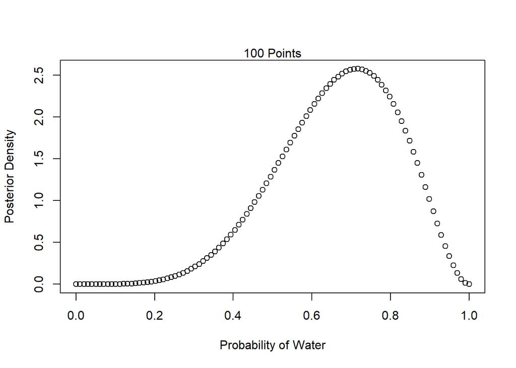

```r
w = 5
n = 7
posterior = compute_posterior(w = w, n = n, prior = prior)
plot_posterior(x = p_grid, y = posterior)
```

##### 【2M2.】

$p < 0.5$の時に$0$，$p \ge 0.5$の時に正の定数となる事前確率を仮定する。2M1の設定に対して同様に事後分布を計算し，グリッド近似をプロットしなさい。

事前分布上の確率密度（prior）を以下のように改める必要がある。

```r
prior = ifelse(p_grid < .5, 0, 1)
```

###### 1.

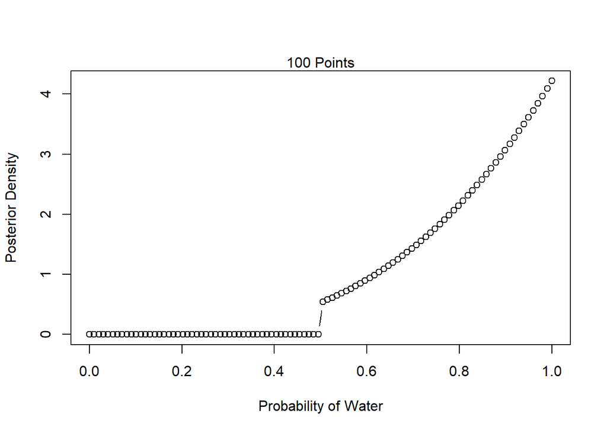

```r
w = 3
n = 3
posterior = compute_posterior(w = w, n = n, prior = prior)
plot_posterior(x = p_grid, y = posterior)
```

###### 2.

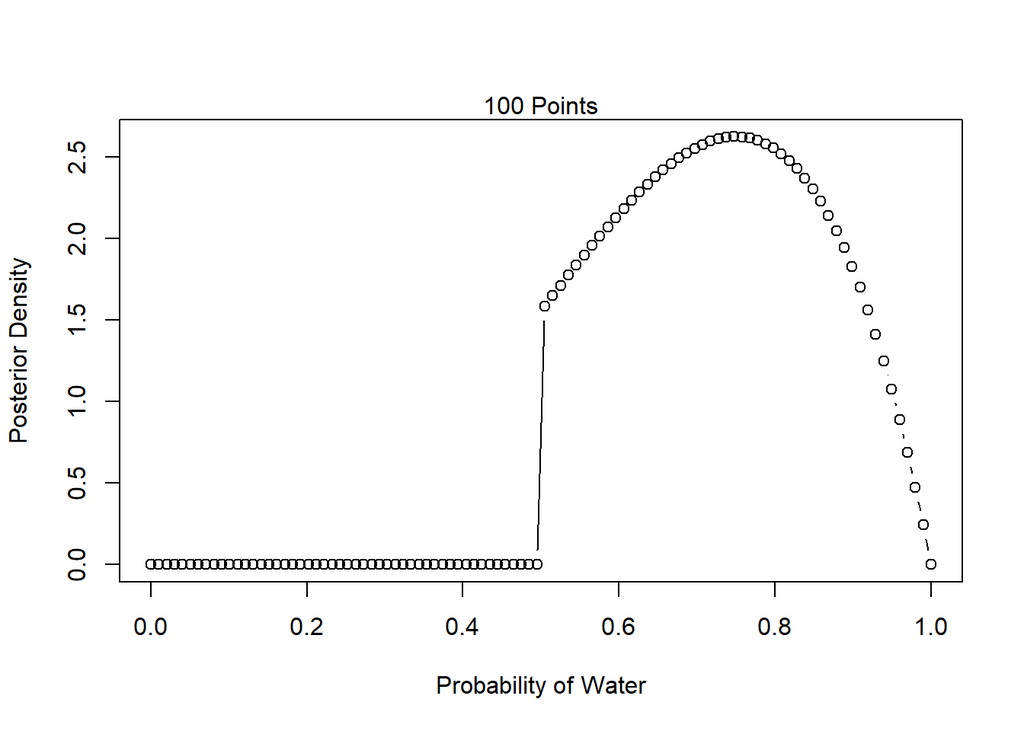

```r
w = 3
n = 4
posterior = compute_posterior(w = w, n = n, prior = prior)
plot_posterior(x = p_grid, y = posterior)
```

###### 3.

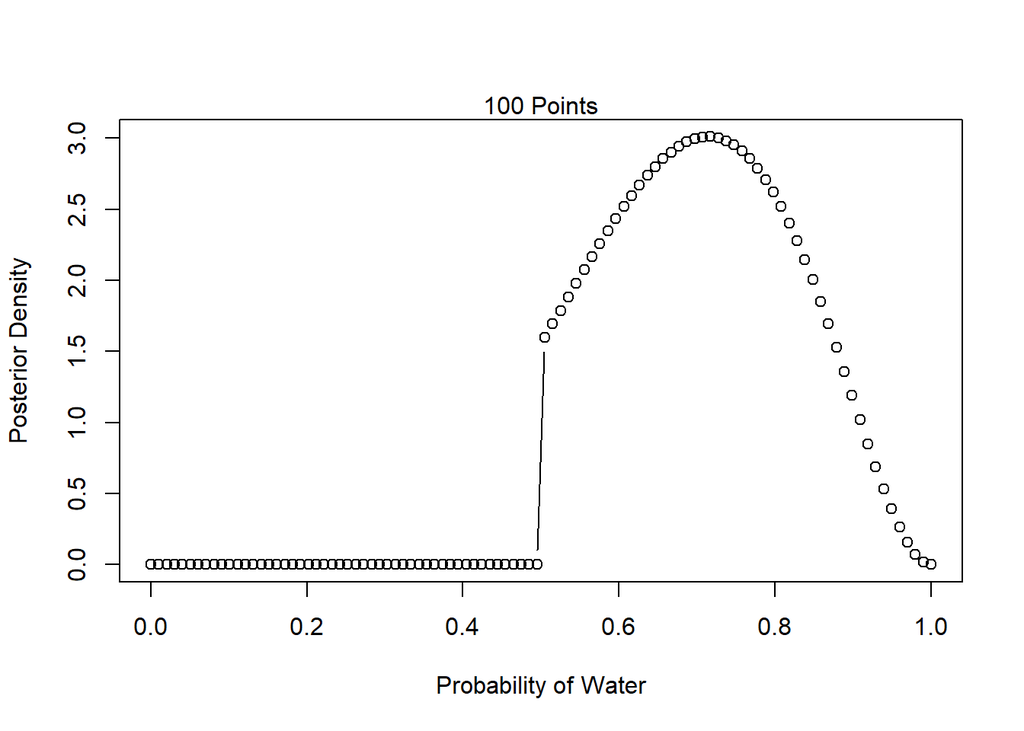

```r
w = 5
n = 7
posterior = compute_posterior(w = w, n = n, prior = prior)
plot_posterior(x = p_grid, y = posterior)
```

##### 【2M3.】

地球儀と火星儀がある。地球儀は$70\%$が海で覆われている。火星儀は$100\%$が陸である。どちらか分からないまま投げ上げ，「陸」が観察されたとしよう。トスされる確率が等しい時，「陸」を確認したという条件の下でそれが地球儀である事後確率$P(Earth | L)$が$0.23$となることを示しなさい。

$$\begin{eqnarray*}
P(Earth | L) &=& \frac{P(L | Earth) P(Earth)}{P(L)} \\
&=& \frac{0.3 \times 0.5}{0.3 \times 0.5 + 1.0 \times 0.5} \\
&\approx& 0.23
\end{eqnarray*}$$

```r
prior = c(.5, .5)
likelihood = c(.3, 1)
unstandardized.posterior = prior * likelihood
posterior = unstandardized.posterior / sum(unstandardized.posterior)
round(posterior[1], 2) == .23
```

```
## [1] TRUE
```

##### 【2M4.】

$3$枚のカードがあり，片面は黒か白のいずれかである。$1$枚は両面黒である。$1$枚は黒と白，$3$枚目は両面白である。これらのカードを袋に入れて混ぜる。袋から$1$枚カードを取り出し，テーブルに置く。黒面が見えるが裏側の色は分からない。一方の面も黒である確率が$2/3$であることを示しなさい。この問題を解く方法として数え上げを用いなさい。つまり，それぞれのカードが観察データ（黒面が見えている）を生じさせるパターンを数え上げなさい。

| カード | 黒 |
| --- | --- |
| 黒黒 | $2$ |
| 黒白 | $1$ |
| 白白 | $0$ |

上表より，
$$\frac{2}{2 + 1 + 0} = \frac{2}{3}$$

```r
bb.likelihood = 2
bw.likelihood = 1
ww.likelihood = 0
likelihood = c(bb.likelihood, bw.likelihood, ww.likelihood)
prior = rep(x = 1, length = length(likelihood))
unstandardized.posterior = prior * likelihood
posterior = unstandardized.posterior / sum(unstandardized.posterior)
posterior[1] == 2/3
```

```
## [1] TRUE
```

##### 【2M5.】

黒黒，黒白，白白，もう$1$枚黒黒の計$4$枚のカードがある。再び袋から$1$枚カードを取り出したら，黒面が現れたとする。一方の面も黒である確率を求めなさい。

| カード | 黒 |
| --- | --- |
| 黒黒 | $2$ |
| 黒白 | $1$ |
| 白白 | $0$ |
| 黒黒 | $2$ |

上表より，
$$\frac{2 + 2}{2 + 1 + 0 + 2} = \frac{4}{5}$$

```r
bb1.likelihood = 2
bw.likelihood = 1
ww.likelihood = 0
bb2.likelihood = 2
likelihood = c(bb1.likelihood, bw.likelihood, ww.likelihood, bb2.likelihood)
prior = rep(x = 1, length = length(likelihood))
unstandardized.posterior = prior * likelihood
posterior = unstandardized.posterior / sum(unstandardized.posterior)
posterior[1] + posterior[4]
```

```
## [1] 0.8
```

##### 【2M6.】

黒インクは重いので，カードの黒面は白面よりも重いとする。その結果，両面が黒のカードは袋から取り出されにくくなる。そこで再び，黒黒，黒白，白白の$3$枚のカードがあるとしよう。何回か取り出したところ，黒黒のカード$1$回に対し，黒白が$2$回，白白が$3$回取り出されるようだった。カードを$1$枚取り出すと黒面が見えたとしよう。一方の面も黒である確率が$0.5$であることを示しなさい。前回同様，数え上げを用いなさい。

| カード | 抽出割合 | 黒 | 積 |
| --- | --- | --- | --- |
| 黒黒 | $1$ | $2$ | $2$ |
| 黒白 | $2$ | $1$ | $2$ |
| 白白 | $3$ | $0$ | $0$ |

```r
bb.likelihood = 2
bw.likelihood = 1
ww.likelihood = 0
likelihood = c(bb.likelihood, bw.likelihood, ww.likelihood)
prior = c(1, 2, 3)
unstandardized.posterior = prior * likelihood
posterior = unstandardized.posterior / sum(unstandardized.posterior)
posterior[1] == .5
```

```
## [1] TRUE
```

##### 【2M7.】

再び，$1$枚カードを取り出したら黒面が見えたという元のカード問題を考える。もう一方の面を確認する前に，もう$1$枚カードを袋から取り出し，テーブルに置いたところ，白面が見えた。黒面が見えている最初のカードのもう一方の面が黒である確率が$0.75$であることを示しなさい。可能であれば，数え上げを用いなさい。＜ヒント＞地球儀トスのように捉え，最初の各カード候補に対して生じ得るデータを全て数え上げなさい。

| 最初カード | 黒 | 次のカード | 白 | 積 |
| --- | --- | --- | --- | --- |
| 黒黒 | $2$ | 黒白 | $1$ | $2$ |
|  |  | 白白 | $2$ | $4$ |
| 黒白 | $1$ | 黒黒 | $0$ | $0$ |
|  |  | 白白 | $2$ | $2$ |
| 白白 | $0$ | 黒黒 | $0$ | $0$ |
|  |  | 黒白 | $1$ | $0$ |

上表より，
$$\frac{2 + 4}{2 + 4 + 2} = \frac{3}{4}$$

```r
bb.bw.likelihood = 2
bb.ww.likelihood = 4
bw.bb.likelihood = 0
bw.ww.likelihood = 2
ww.bb.likelihood = 0
ww.bw.likelihood = 0
likelihood = c(bb.bw.likelihood, bb.ww.likelihood, bw.bb.likelihood, bw.ww.likelihood, ww.bb.likelihood, ww.bw.likelihood)
prior = rep(x = 1, length = length(likelihood))
unstandardized.posterior = prior * likelihood
posterior = unstandardized.posterior / sum(unstandardized.posterior)
posterior[1] + posterior[2] == .75
```

```
## [1] TRUE
```

> HARD

##### 【2H1.】

$2$種類のパンダがいる。両方とも同じエリアに等しく分布している。見た目も非常に似ていて食べ物も同じである。区別できる遺伝子解析もまだない。しかし，家族サイズが異なる。種Aは$10\%$の確率で双子を産み，それ以外は$1$匹産む。種Bは$20\%$の確率で双子を産み，それ以外は$1$匹産む。長年のフィールド研究からこの数値はよく分かっているとしよう。今，あなたはパンダ繁殖プログラムを取り仕切る立場にある。種が不明のメスパンダが双子を出産した。そのパンダが種Aである確率を計算しなさい。

$P(twin | A) = 0.1$，$P(twin | B) = 0.2$であり，それぞれの種の分布は等しいことから$P(A) = P(B) = 0.5$と仮定できる。
$$P(A | twin) = \frac{P(twin | A) P(A)}{P(twin | A) P(A) + P(twin | B) P(B)} = \frac{0.1 \times 0.5}{0.1 \times 0.5 + 0.2 \times 0.5} = \frac{1}{3}$$

```r
species.A.likelihood = .1
species.B.likelihood = .2
likelihood = c(species.A.likelihood, species.B.likelihood)
prior = c(1, 1)
unstandardized.posterior = likelihood * prior
posterior = unstandardized.posterior / sum(unstandardized.posterior)
posterior[1]
```

```
## [1] 0.3333333
```

##### 【2H2.】

前問の設定を再度考えよう。このパンダが次の出産でも双子を産む確率を求めなさい。

$$P(B | twin) = 1 - P(A | twin) = 1 - \frac{1}{3} = \frac{2}{3}$$
次に双子を産む確率は，
$$P(A | twin) \times 0.1 + P(B | twin) \times 0.2 = \frac{1}{3} \times 0.1 + \frac{2}{3} \times 0.2 = \frac{1}{6}$$

```r
posterior[1] * .1 + posterior[2] * .2
```

```
## [1] 0.1666667
```

##### 【2H3.】

前問を続けよう。同じ母パンダが$2$度目の出産をしたが，今度は双子ではなく$1$匹であった。このパンダが種Aである事後確率を計算しなさい。

$$\begin{eqnarray*}
P(A | single, twin) &=& \frac{P(single, twin | A) P(A)}{P(single, twin | A) P(A) + P(single, twin | B) P(B)} \\
&=& \frac{P(single | A) P(twin | A) P(A)}{P(single | A) P(twin | A) P(A) + P(single | B) P(twin | B) P(B)} \\
&=& \frac{0.9 \times 0.1 \times 0.5}{0.9 \times 0.1 \times 0.5 + 0.8 \times 0.2 \times 0.5} \\
&=& \frac{9}{25}
\end{eqnarray*}$$

```r
species.A.likelihood = .1 * (1 - .1)
species.B.likelihood = .2 * (1 - .2)
likelihood = c(species.A.likelihood, species.B.likelihood)
prior = c(1, 1)
unstandardized.posterior = likelihood * prior
posterior = unstandardized.posterior / sum(unstandardized.posterior)
posterior[1]
```

```
## [1] 0.36
```

##### 【2H4.】

ベイズ統計学者は，たとえデータの種類がまちまちであっても，ベイズ推論は全てのデータを用意に扱えると豪語することがしばしばある。

そこで，新たな遺伝子検査で母パンダの種を特定できると言い張るある獣医師がやってくるとしよう。しかし，従来の全ての検査同様，このテストもまた不完全である。テストについて掴んだ情報は以下の通り：

- 種Aのパンダであると正しく特定する確率は$0.8$。
- 種Bのパンダであると正しく特定する確率は$0.65$。

獣医師はパンダを検査し，種Aについて陽性であると言う。最初に出産に関する以前の情報を棚上げし，パンダが種Aである事後確率を計算しなさい。その後，出産データを加味して再計算しなさい。

###### without birth information

$$\begin{eqnarray*}
P(A | positive) &=& \frac{P(positive | A) P(A)}{P(positive | A) P(A) + P(negative | B) P(B)} \\
&=& \frac{0.8 \times 0.5}{0.8 \times 0.5 + (1 - 0.65) \times 0.5} \\
&=& \frac{16}{23}
\end{eqnarray*}$$

```r
species.A.likelihood = .8
species.B.likelihood = .65
likelihood = c(species.A.likelihood, 1 - species.B.likelihood)    # 2つ目は偽陽性
prior = c(1, 1)
unstandardized.posterior = likelihood * prior
posterior.vet.test = unstandardized.posterior / sum(unstandardized.posterior)
posterior.vet.test[1]
```

```
## [1] 0.6956522
```

###### with birth information

$$\begin{eqnarray*}
& & P(A | positive, single, twin) \\
&=& \frac{P(positive, single, twin | A) P(A)}{P(positive, single, twin | A) P(A) + P(negative, single, twin | B) P(B)} \\
&=& \frac{P(positive | A) P(single | A) P(twin | A) P(A)}{P(positive | A) P(single | A) P(twin | A) P(A) + P(negative | B) P(single | B) P(twin | B) P(B)} \\
&=& \frac{0.8 \times 0.9 \times 0.1 \times 0.5}{0.8 \times 0.9 \times 0.1 \times 0.5 + (1 - 0.65) \times 0.8 \times 0.2 \times 0.5} \\
&=& \frac{9}{16}
\end{eqnarray*}$$

```r
species.A.likelihood = .1 * (1 - .1)
species.B.likelihood = .2 * (1 - .2)
likelihood = c(species.A.likelihood, species.B.likelihood)
prior = c(1, 1)
unstandardized.posterior = likelihood * prior
posterior.birth.info = unstandardized.posterior / sum(unstandardized.posterior)

composite.unstandardized.posterior = posterior.vet.test * posterior.birth.info
composite.posterior = composite.unstandardized.posterior / sum(composite.unstandardized.posterior)
composite.posterior[1]
```

```
## [1] 0.5625
```